# Bellabeat Project

Monika Mangla

2024-08-27

## About the company

*Urška Sršen* and *Sando Mur* founded Bellabeat, a high-tech company that manufactures health-focused smart products. Sršen used her background as an art ist to develop beautifully designed technology that informs and inspires women around the world. Collecting data on activity, sleep, stress, and reproductive health has allowed Bellabeat to empower women with knowledge about their own health and habits. Since it was founded in 2013, Bellabeat has grown rapidly and quickly positioned itself as a tech-driven wellness company for women.

## Products offered by the company

- **Bellabeat app:** The Bellabeat app provides users with health data related to their activity, sleep, stress, menstrual cycle, and mindfulness habits. This data can help users bett er understand their current habits and make healthy decisions. The Bellabeat app connects to their line of smart wellness products.
- **Leaf:** Bellabeat’s classic wellness tracker can be worn as a bracelet, necklace, or clip. The Leaf tracker connects to the Bellabeat app to track activity, sleep, and stress.
- **Time:** This wellness watch combines the timeless look of a classic timepiece with smart technology to track user activity, sleep, and stress. The Time watch connects to the Bellabeat app to provide you with insights into your daily wellness.
- **Spring:** This is a water bott le that tracks daily water intake using smart technology to ensure that you are appropriately hydrated throughout the day. The Spring bott le connects to the Bellabeat app to track your hydration levels.
- **Bellabeat membership:** Bellabeat also off ers a subscription-based membership program for users. Membership gives users 24/7 access to fully personalized guidance on nutrition, activity, sleep, health and beauty, and mindfulness based on their lifestyle and goals.

### We are going to apply different phases of analysis process which are **Ask**, **Prepare**, **Process**, **Analyze**, **Share** and **Act**

# Ask Phase

### Identify the business task:

Analyze smart device usage data in order to gain insight into how consumers use non-Bellabeat smart devices. Following are the questions that will help in our analysis which are as follows:

1. What are some trends in smart device usage?
2. How could these trends apply to Bellabeat customers?
3. How could these trends help infl uence Bellabeat marketing strategy?

### Consider key stakeholders:

- **Urška Sršen**: Bellabeat’s cofounder and Chief Creative Officer
- **Sando Mur**: Mathematician and Bellabeat’s cofounder; key member of the Bellabeat executive team.

# Prepare Phase

### Dataset

**FitBit Fitness Tracker Data** is a Kaggle data set contains personal fi tness tracker from thirt y fi tbit users. Thirt y eligible Fitbit users consented to the submission of personal tracker data, including minute-level output for physical activity, heart rate, and sleep monitoring. It includes information about daily activity, steps, and heart rate that can be used to explore users’ habits.

### Data Organization

This dataset contains CSV files that stores the data customer data on daily, hourly and minutes basis. It includes various csv files such as

- dailyActivity_merged.csv
- dailyCalories_merged.csv
- dailyIntensities_merged.csv
- dailySteps_merged.csv
- hourlyCalories_merged.csv
- hourlyIntensities_merged.csv
- hourlySteps_merged.csv
- sleepDay_merged.csv
- weightLogInfo_merged.csv

The data is organized in rows and columns, therefore it is a structured data. Each csv file have session Id as a common column that corresponds to have data in multiple rows.

Data has been categorized into three time frames:

1. Daily data
2. Hourly data
3. Minute data

By analyzing the daily, hourly, and minute level data provided, we can begin to explore trends and search for insights that can be applied to Bellabeat customers.

# Process Phase

We are going to use R Progamming language using **RStudio**.

## Why R?

R is a programming language that’s popular in data science and is known for its data visualization capabilities. It offers a variety of tools and libraries that allow users to create visual representations of their data, and is often preferred for translating complex data into intuitive formats.

### Importing the data

We are going to load daily and hourly datasets only because in minutes dataset if we combine the files then also we are not going to get useful results instead it occupies R’s RAM that may affect our execution.

```r
daily_activity <- read.csv("dailyActivity_merged.csv")
daily_calories <- read.csv("dailyCalories_merged.csv")
daily_intensities <- read.csv("dailyIntensities_merged.csv")
daily_steps <- read.csv("dailySteps_merged.csv")
heart_rate <- read.csv("heartrate_seconds_merged.csv")
hourly_calories <- read.csv("hourlyCalories_merged.csv")
hourly_intensities <- read.csv("hourlyIntensities_merged.csv")
hourly_steps <- read.csv("hourlySteps_merged.csv")
sleep_day <- read.csv("sleepDay_merged.csv")
weight_log_info <- read.csv("weightLogInfo_merged.csv")
```

Due to large size of minute dataset we are going to import only minutes sleep data.

```r
minute_sleep <- read.csv("minuteSleep_merged.csv")
```

## Familiarization with data

Let’s start by examining the data by extracting column names and first few rows using **colnames()** and **head()** function.

##### Daily datasets

`head(dailyActivity_merged)` `colnames(dailyActivity_merged)`

`head(dailyCalories_merged)` `colnames(dailyCalories_merged)`

`head(dailyIntensities_merged)` `colnames(dailyIntensities_merged)`

`head(dailySteps_merged)` `colnames(dailySteps_merged)`

`head(sleepDay_merged)` `colnames(sleepDay_merged)`

`head(weightLogInfo_merged)` `colnames(weightLogInfo_merged)`

##### Hourly datasets

`head(hourlyCalories_merged)` `colnames(hourlyCalories_merged)`

`head(hourlyIntensities_merged)` `colnames(hourlyIntensities_merged)`

`head(hourlySteps_merged)` `colnames(hourlySteps_merged)`

##### Minute datasets

`head(minuteSleep_merged)` `colnames(minuteSleep_merged)`

Now, let’s examine some columns for further exploration using **select()** function.

##### For daily datasets

```r
dailyActivity_merged %>%
  select(id, activity_date)
dailyCalories_merged %>%
  select(Id, ActivityDay)
dailyIntensities_merged %>%
  select(Id, ActivityDay)
dailySteps_merged %>%
  select(Id, ActivityDay)
sleepDay_merged %>%
  select(Id, SleepDay)
weightLogInfo_merged %>%
  select(Id, Date)
```

##### For hourly datasets

```r
hourlyCalories_merged %>%
  select(Id, ActivityHour)
hourlyIntensities_merged %>%
  select(Id, ActivityHour)
hourlySteps_merged %>%
  select(Id, ActivityHour)
```

##### For minute dataset

```r
minuteSleep_merged %>%
  select(Id, date)
```

## Data Cleaning

Now we got familiarize with variables its time to do data cleaning process. In this we are going to do

- naming conventions using **rename()** ,
- changing the date format into *%y/%m/%d* using **as.Date()**,
- converting column names into lowercase using **tolower()**
- creating some new variables like *day_of_week* and *time_of_week*

#### For daily datasets

————-Daily Activity—————

```r
dailyActivity_merged <-
  dailyActivity_merged %>%
  rename(
    activity_date = ActivityDate,
    total_steps = TotalSteps,
    total_distance = TotalDistance,
    tracker_distance = TrackerDistance,
    logged_activities_d = LoggedActivitiesDistance,
    very_active_d = VeryActiveDistance,
    moderately_active_d = ModeratelyActiveDistance,
    light_active_d = LightActiveDistance,
    sedentary_d = SedentaryActiveDistance,
    very_active_m = VeryActiveMinutes,
    fairly_active_m = FairlyActiveMinutes,
    lightly_active_m = LightlyActiveMinutes,
    sedentary_m = SedentaryMinutes,
    calories = Calories
  ) %>%
  rename_with(
    tolower, starts_with("Id")
  ) %>%
  mutate(
    # reformat variable as POSIXct to represent date and time
    activity_date = parse_date_time(activity_date, "%m/%d/%y"),
    # create new variable and format as date only
    activity_date_ymd = as.Date(activity_date, "%Y/%m/%d"),
    # create new variables for day of week and time of week
    day_of_week = weekdays(as.Date(activity_date)),
    time_of_week = case_when(
      day_of_week %in% c("Monday", "Tuesday", "Wednesday", "Thursday", "Friday") ~ "Weekday",
      day_of_week %in% c("Saturday", "Sunday") ~ "Weekend")
  )
```

————-Daily Calories—————–

```r
dailyCalories_merged <-
  dailyCalories_merged %>%
  rename(
    activity_date = ActivityDay,
    calories = Calories
  ) %>%
  rename_with(
    tolower, starts_with("Id")
  ) %>%
  mutate(
    activity_date = parse_date_time(activity_date, "%m/%d/%Y"),
    activity_date_ymd = as.Date(activity_date, "%Y/%m/%d"),
    day_of_week = weekdays(as.Date(activity_date)),
    time_of_week = case_when(
      day_of_week %in% c("Monday", "Tuesday", "Wednesday", "Thursday", "Friday") ~ "Weekday",
      day_of_week %in% c("Saturday", "Sunday") ~ "Weekend")
  )
```

—————–Daily Intensities———–

```r
dailyIntensities_merged <-
  dailyIntensities_merged %>%
  rename(
    activity_date = ActivityDay,
    very_active_d = VeryActiveDistance,
    moderately_active_d = ModeratelyActiveDistance,
    light_active_d = LightActiveDistance,
    sedentary_d = SedentaryActiveDistance,
    very_active_m = VeryActiveMinutes,
    fairly_active_m = FairlyActiveMinutes,
    lightly_active_m = LightlyActiveMinutes,
    sedentary_m = SedentaryMinutes,
  ) %>%
  rename_with(
    tolower, starts_with("Id")
  ) %>%
  mutate(
    activity_date = parse_date_time(activity_date, "%m/%d/%Y"),
    activity_date_ymd = as.Date(activity_date, "%Y/%m/%d"),
    day_of_week = weekdays(as.Date(activity_date)),
    time_of_week = case_when(
      day_of_week %in% c("Monday", "Tuesday", "Wednesday", "Thursday", "Friday") ~ "Weekday",
      day_of_week %in% c("Saturday", "Sunday") ~ "Weekend")
  )
```

—————–Daily Sleep————————

```r
sleepDay_merged <-
  sleepDay_merged %>%
  rename(
    activity_date = SleepDay,
    total_sleep_records = TotalSleepRecords,
    total_minutes_asleep = TotalMinutesAsleep,
    total_time_in_bed = TotalTimeInBed
  ) %>%
  rename_with(
    tolower, starts_with("Id")
  ) %>%
  mutate(
    activity_date = parse_date_time(activity_date, "%m/%d/%Y %I:%M:%S %p"),
    activity_date_ymd = as.Date(activity_date, "%Y/%m/%d"),
    day_of_week = weekdays(as.Date(activity_date)),
    time_of_week = case_when(
      day_of_week %in% c("Monday", "Tuesday", "Wednesday", "Thursday", "Friday") ~ "Weekday",
      day_of_week %in% c("Saturday", "Sunday") ~ "Weekend")
  )
```

——————-Daily Steps———————-

```r
dailySteps_merged <-
  dailySteps_merged %>%
  rename(
    activity_date = ActivityDay,
    step_total = StepTotal
  ) %>%
  rename_with(
    tolower, starts_with("Id")
  ) %>%
  mutate(
    activity_date = parse_date_time(activity_date, "%m/%d/%Y"),
    activity_date_ymd = as.Date(activity_date, "%Y/%m/%d"),
    day_of_week = weekdays(as.Date(activity_date)),
    time_of_week = case_when(
      day_of_week %in% c("Monday", "Tuesday", "Wednesday", "Thursday", "Friday") ~ "Weekday",
      day_of_week %in% c("Saturday", "Sunday") ~ "Weekend")
  )
```

——————-Weigth Log————-

```r
weightLogInfo_merged <-
  weightLogInfo_merged %>%
  rename(
    activity_date = Date,
    weight_kg = WeightKg,
    weight_lb = WeightPounds,
    fat = Fat,
    bmi = BMI,
    manual_report = IsManualReport,
    log_id = LogId
  ) %>%
  rename_with(
    tolower, starts_with("Id")
  ) %>%
  mutate(
    activity_date = parse_date_time(activity_date, "%m/%d/%Y %I:%M:%S %p"),
    activity_date_ymd = as.Date(activity_date, "%Y/%m/%d"),
    activity_time = format(activity_date, format = "%I:%M:%S %p"),
    day_of_week = weekdays(as.Date(activity_date)),
    time_of_week = case_when(
      day_of_week %in% c("Monday", "Tuesday", "Wednesday", "Thursday", "Friday") ~ "Weekday",
      day_of_week %in% c("Saturday", "Sunday") ~ "Weekend"),
    hour_of_day = as.POSIXct(activity_date, format = "%I:%M:%S %p")
  )
```

##### For hourly datasets

—————Hourly Calories—————-

```r
hourlyCalories_merged <-
  hourlyCalories_merged %>%
  rename(
    activity_hour = ActivityHour,
    calories = Calories
  ) %>%
  rename_with(
    tolower, starts_with("Id")
  ) %>%
  mutate(
    activity_hour = parse_date_time(activity_hour, "%m/%d/%Y %I:%M:%S %p"),
    activity_date_ymd = as.Date(activity_hour, "%Y/%m/%d"),
    activity_time = format(activity_hour, format = "%I:%M:%S %p"),
    day_of_week = weekdays(as.Date(activity_hour)),
    time_of_week = case_when(
      day_of_week %in% c("Monday", "Tuesday", "Wednesday", "Thursday", "Friday") ~ "Weekday",
      day_of_week %in% c("Saturday", "Sunday") ~ "Weekend"),
    hour_of_day = as.POSIXct(activity_time, format = "%I:%M:%S %p"))
```

—————-Hourly Intenstities———————–

```r
hourlyIntensities_merged <-
  hourlyIntensities_merged %>%
  rename(
    activity_hour = ActivityHour,
    total_intensity = TotalIntensity,
    average_intensity = AverageIntensity
  ) %>%
  rename_with(
    tolower, starts_with("Id")
  ) %>%
  mutate(
    activity_hour = parse_date_time(activity_hour, "%m/%d/%Y %I:%M:%S %p"),
    activity_date_ymd = as.Date(activity_hour, "%Y/%m/%d"),
    activity_time = format(activity_hour, format = "%I:%M:%S %p"),
    day_of_week = weekdays(as.Date(activity_hour)),
    time_of_week = case_when(
      day_of_week %in% c("Monday", "Tuesday", "Wednesday", "Thursday", "Friday") ~ "Weekday",
      day_of_week %in% c("Saturday", "Sunday") ~ "Weekend"),
    hour_of_day = as.POSIXct(activity_time, format = "%I:%M:%S %p")
  )
```

———————Hourly Steps———————

```r
hourlySteps_merged <-
  hourlySteps_merged %>%
  rename(
    activity_hour = ActivityHour,
    step_total = StepTotal
  ) %>%
  rename_with(
    tolower, starts_with("Id")
  ) %>%
  mutate(
    activity_hour = parse_date_time(activity_hour, "%m/%d/%Y %I:%M:%S %p"),
    activity_date_ymd = as.Date(activity_hour, "%Y/%m/%d"),
    activity_time = format(activity_hour, format = "%I:%M:%S %p"),
    day_of_week = weekdays(as.Date(activity_hour)),
    time_of_week = case_when(
      day_of_week %in% c("Monday", "Tuesday", "Wednesday", "Thursday", "Friday") ~ "Weekday",
      day_of_week %in% c("Saturday", "Sunday") ~ "Weekend"),
    hour_of_day = as.POSIXct(activity_time, format = "%I:%M:%S %p")
  )
```

##### For minute dataset

———————minutes sleep———————

```r
minuteSleep_merged <-
  minuteSleep_merged %>%
  rename(
    activity_date = date,
    sleep_value = value,
    log_id = logId
  ) %>%
  rename_with(
    tolower, starts_with("Id")
  ) %>%
  mutate(
    activity_date = parse_date_time(activity_date, "%m/%d/%Y %I:%M:%S %p"),
    activity_date_ymd = as.Date(activity_date, "%Y/%m/%d"),
    activity_time = format(activity_date, format = "%I:%M:00 %p"),
    day_of_week = weekdays(as.Date(activity_date)),
    time_of_week = case_when(
      day_of_week %in% c("Monday", "Tuesday", "Wednesday", "Thursday", "Friday") ~ "Weekday",
      day_of_week %in% c("Saturday", "Sunday") ~ "Weekend"),
    hour_of_day = as.POSIXct(activity_time, format = "%I:%M:%S %p"),
    # sleep_id will be used generate totals per sleep log
    sleep_id = str_c(id, "-", log_id),
    # Create new variables for sleep values - asleep, restless, and awake
    asleep = ifelse(sleep_value == 1, 1, 0),
    restless = ifelse(sleep_value == 2, 1, 0),
    awake = ifelse(sleep_value == 3, 1, 0)
  )
```

Create sleep_summary_0 dataset that shows totals for 3 sleep values per sleep log like *total_asleep*,*total_restless* and *total_awake*.

```r
sleep_summary_0 <-
  minuteSleep_merged %>%
  # id_date will be used to generate a daily total
  mutate(
    id_date = str_c(id, "-", activity_date_ymd)
  ) %>%
  group_by(sleep_id, activity_date_ymd, id_date, id) %>%
  dplyr::summarize(
    total_asleep = sum(sleep_value == "1"),
    total_restless = sum(sleep_value == "2"),
    total_awake = sum(sleep_value == "3")
  )
```

Create sleep_data dataset that combines totals for each day per id.

```r
sleep_summary <-
  sleep_summary_0 %>%
  # activity_date will be used to merge with daily_sleep df
  mutate(
    activity_date = parse_date_time(activity_date_ymd, "%Y/%m/%d")
  ) %>%
  group_by(id_date, activity_date, id) %>%
  dplyr::summarize(
    total_asleep_merged = sum(total_asleep),
    total_restless_merged = sum(total_restless),
    total_awake_merged = sum(total_awake)
  )
# Merge these two daily sleep dfs into one ---------------------------
sleep_data <- merge(x = sleepDay_merged, y = sleep_summary, by = c("id", "activity_date"), all = TRUE)
```

# Analyze Phase

Since we have imported our dataset as well as clean our data by formatting and creating new variables now it’s time to have deep analysis of our data using statistical analysis.

### 1) Finding unique users as per id

We are going to find out how many unique participants are there corresponding to their session_id using **n_distinct()**.

##### For daily dataset

```r
# There are 33 users in the daily activity dataset
n_distinct(dailyActivity_merged$id)
# There are 24 users in the sleep datasets
n_distinct(sleepDay_merged$id)
n_distinct(sleep_data$id)
# There are 8 users in the weight dataset
n_distinct(weightLogInfo_merged$id)
```

##### For hourly dataset

```r
# There are 33 users in the hourly datasets
n_distinct(hourlyCalories_merged$id)
n_distinct(hourlyIntensities_merged$id)
n_distinct(hourlySteps_merged$id)
```

##### For minute dataset

```r
# There are 24 users in the minute dataset
n_distinct(minuteSleep_merged$id)
```

### 2) Finding total number of observations/rows in each dataset

Lets find out how many total observations are there in each dataset using **nrow()**.

##### For daily dataset

```r
# There are total 940 observations in daily activity dataset
nrow(dailyActivity_merged)
# There are total 940 observations in daily steps dataset
nrow(dailySteps_merged)
# There are total 452 observations in sleep data dataset
nrow(sleep_data)
# There are total 67 observations in weight log dataset
nrow(weightLogInfo_merged)
```

##### For hourly dataset

```r
# There are 22099 observations in each hourly dataset
nrow(hourlyCalories_merged)
nrow(hourlyIntensities_merged)
nrow(hourlySteps_merged)
```

##### For minute dataset

```r
# There are 188521 observations in the minute dataframe
nrow(minuteSleep_merged)
```

### 3) Finding statistics for each dataset

Lets figure out some statistical analysis of each dataset using **summary()** .

##### For daily dataset

- Daily totals for steps, distance, calories:

```r
dailyActivity_merged %>%
  select(
    total_steps,
    total_distance,
    calories
  ) %>%
  summary()
```

[output not shown]

- Active minute levels per category:

```r
dailyActivity_merged %>%
  select(
    very_active_m,
    fairly_active_m,
    lightly_active_m,
    sedentary_m
  ) %>%
  summary()
```

[output not shown]

- Sleep totals for records, minutes asleep, and time in bed:

```r
sleepDay_merged %>%
  select(
    total_sleep_records,
    total_minutes_asleep,
    total_time_in_bed
  ) %>%
  summary()
```

[output not shown]

- Sleep totals per category:

```r
sleep_data %>%
  select(
    total_minutes_asleep,
    total_time_in_bed,
    total_asleep_merged,
    total_restless_merged,
    total_awake_merged
  ) %>%
  summary()
```

[output not shown]

- Weight totals:

```r
weightLogInfo_merged %>%
  select(
    weight_lb,
    fat,
    bmi
  ) %>%
  summary()
```

[output not shown]

##### For hourly dataset

- Hourly calories summary:

```r
hourlyCalories_merged %>%
  select(calories) %>%
  summary()
```

[output not shown]

- Hourly intensities summary:

```r
hourlyIntensities_merged %>%
  select(
    total_intensity,
    average_intensity
  ) %>%
  summary()
```

[output not shown]

- Hourly steps summary:

```r
hourlySteps_merged %>%
  select(step_total) %>%
  summary()
```

[output not shown]

##### For minute dataset

- Minute sleep summary:

```r
minuteSleep_merged %>%
  select(
    sleep_value,
    asleep,
    restless,
    awake
  ) %>%
  summary()
```

[output not shown]

## 4) Useful Insights from this analysis

- It is recommended to have 10K steps daily for a healthy lifestyle but our data shows *7,368* which is less.
- *991.2* - average “Sedentary” minutes per day, which is the highest average of the tracked activity minutes per day. This is just over 16.5 hours per day.
- *192.8*- average “Lightly Active” minutes per day, which the highest among the non-sedentary activity minutes per day (*21.16* - Very Active, *13.56*- Fairly Active).
- *34.72* - combined daily average of Very Active (21.16) and Fairly Active (13.56) minutes per day. This indicates that, on average, these individuals may mostly be getting the WHO recommended 150 minutes of moderate-intensity physical activity per week.
- *91.5%* - average percentage of time asleep while in bed. This is calculated by dividing “Total Minutes Asleep” (419.5) by “Total Time In Bed” (458.6).
- *97.39* - average calories burned per hour.

# Act Phase

Now we have done with our analysis its time to create some interactive visualization and find out the relationships & trends. We are going to use **ggplot()** for data visualization.

## Total steps vs calories plot

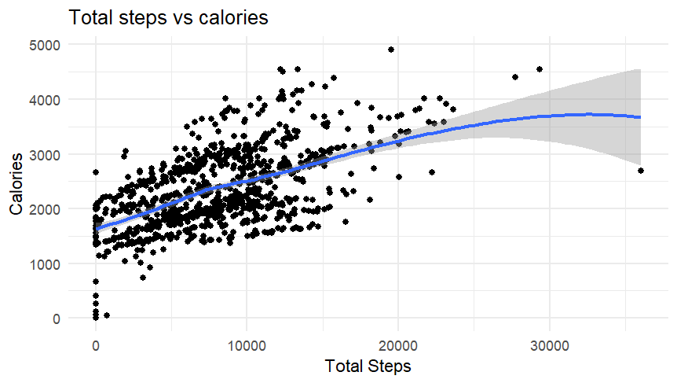

```r
ggplot(data = dailyActivity_merged, aes(x = total_steps, y = calories)) +
  geom_point() +
  geom_smooth() + # Trend line with a shadow representing  95% confidence interval
  labs(title = "Total steps vs calories") +
  ylab("Calories") +
  xlab("Total Steps") +
  theme_minimal()
cor.test(dailyActivity_merged$total_steps, dailyActivity_merged$calories, method = "pearson")
```

[output not shown]

#### Insights:

- **Total Steps** and **Calories** are interrelated with each other.
- More steps leads to more calories burn which in turn make lifestyle healthy.

## Very Active Minutes vs Calories

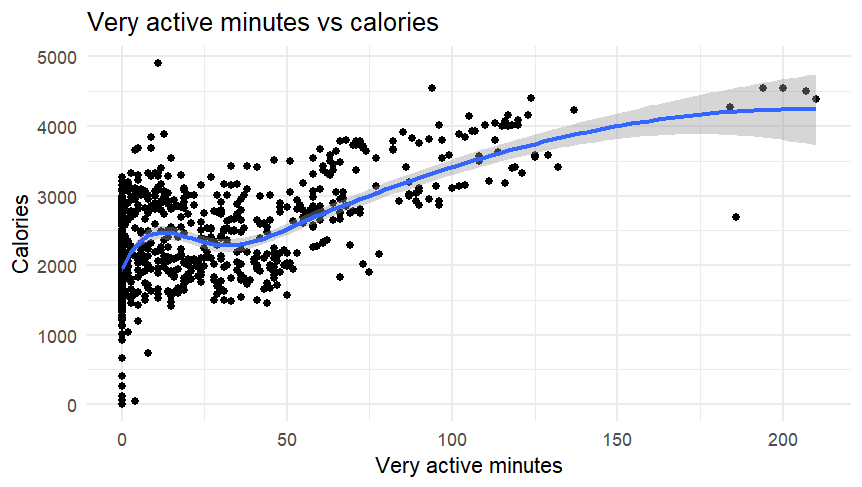

```r
ggplot(data = dailyActivity_merged, aes(x = very_active_m, y = calories)) +
  geom_point() +
  geom_smooth() + # Trend line with a shadow representing  95% confidence interval
  labs(title = "Very active minutes vs calories") +
  ylab("Calories") +
  xlab("Very active minutes") +
  theme_minimal()
cor.test(dailyActivity_merged$very_active_m, dailyActivity_merged$calories, method = "pearson")
```

[output not shown]

## Light Active Minutes vs Calories

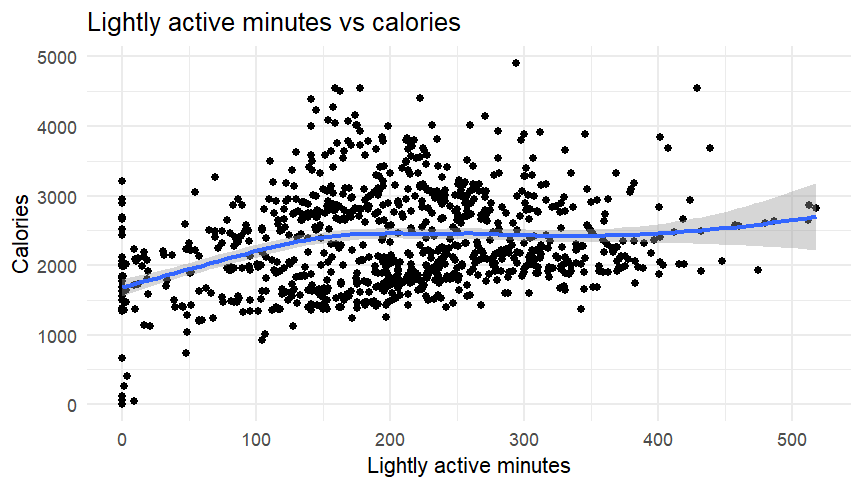

```r
ggplot(data = dailyActivity_merged, aes(x = lightly_active_m, y = calories)) +
  geom_point() +
  geom_smooth() + # Trend line with a shadow representing  95% confidence interval
  labs(title = "Lightly active minutes vs calories") +
  ylab("Calories") +
  xlab("Lightly active minutes") +
  theme_minimal()
cor.test(dailyActivity_merged$lightly_active_m, dailyActivity_merged$calories, method = "pearson")
```

[output not shown]

#### Insights:

- Light active minutes have less impact on calories burnt throughout the day.

## Calories vs Day of Week

First of all let’s create some labels

```r
labels_weekdays <- c(
  "Monday" = "Monday", "Tuesday" = "Tuesday",
  "Wednesday" = "Wednesday", "Thursday" = "Thursday",
  "Friday" = "Friday", "Saturday" = "Saturday",
  "Sunday" = "Sunday"
)
limits_weekdays <- c(
  "Monday", "Tuesday", "Wednesday", "Thursday", "Friday",
  "Saturday", "Sunday"
)
```

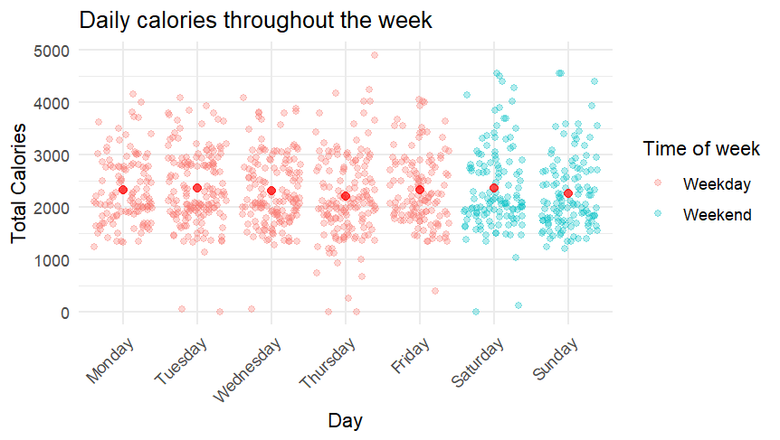

```r
ggplot(data = dailyActivity_merged) +
  geom_point(
    aes(x = day_of_week, y = calories, color = as.factor(time_of_week)),
    position = "jitter",
    alpha = 0.3
  ) +
  labs(title = "Daily calories throughout the week", color = "Time of week") +
  ylab("Total Calories") +
  scale_x_discrete(
    "Day",
    labels = labels_weekdays,
    limits = limits_weekdays,
    guide = guide_axis(angle = 45)
  ) +
  stat_summary(
    aes(x = day_of_week, y = calories),
    fun = mean,
    geom = "point",
    color = "red",
    size = 2,
    alpha = 0.7
  ) +
  theme_minimal()
```

#### Insights:

- There is no large difference between average calories burnt in a day.

## Total minutes asleep vs time of week

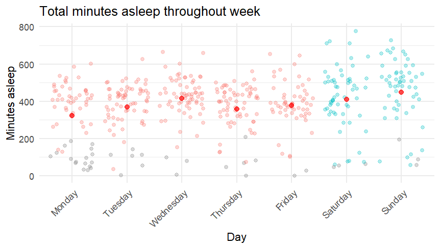

```r
ggplot(data = sleep_data) +
  geom_point(
    aes(
      x = weekdays.POSIXt(activity_date),
      y = total_asleep_merged,
      color = as.factor(time_of_week)
    ),
    position = "jitter",
    alpha = 0.3
  ) +
  labs(title = "Total minutes asleep throughout week") +
  guides(color = "none") +
  ylab("Minutes asleep") +
  scale_x_discrete(
    "Day",
    labels = labels_weekdays,
    limits = limits_weekdays,
    guide = guide_axis(angle = 45)
  ) +
  stat_summary(
    aes(x = weekdays.POSIXt(activity_date), y = total_asleep_merged),
    fun = mean,
    geom = "point",
    color = "red",
    size = 2,
    alpha = 0.7
  ) +
  theme_minimal()
```

#### Insights:

- The average total minutes sleep were highest on Sunday, Wednesday and Saturday

## Total minutes restless vs time of week

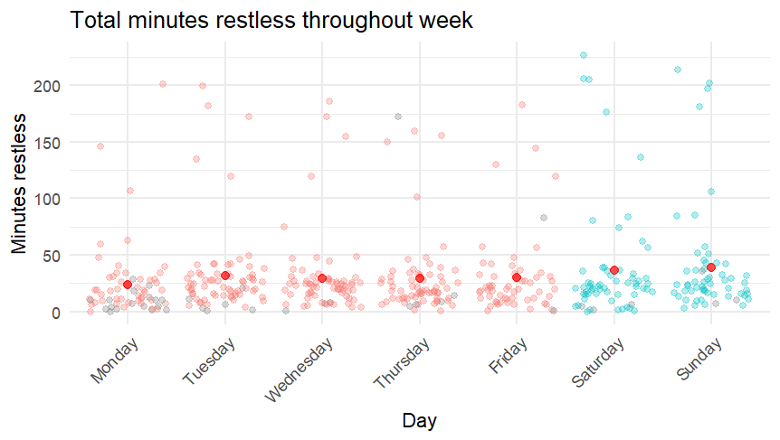

```r
ggplot(data = sleep_data) +
  geom_point(
    aes(
      x = weekdays.POSIXt(activity_date),
      y = total_restless_merged,
      color = as.factor(time_of_week)
    ),
    position = "jitter",
    alpha = 0.3
  ) +
  labs(title = "Total minutes restless throughout week") +
  guides(color = "none") +
  ylab("Minutes restless") +
  scale_x_discrete(
    "Day",
    labels = labels_weekdays,
    limits = limits_weekdays,
    guide = guide_axis(angle = 45)
  ) +
  stat_summary(
    aes(x = weekdays.POSIXt(activity_date), y = total_restless_merged),
    fun = mean,
    geom = "point",
    color = "red",
    size = 2,
    alpha = 0.7
  ) +
  theme_minimal()
```

#### Insights:

- The average for minutes restless were highest on Sunday and Saturday.

## Total minutes awake vs time of week

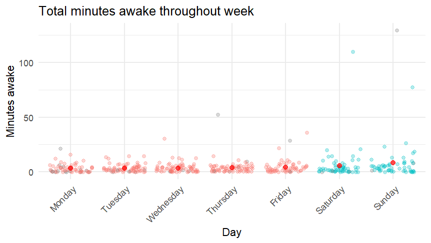

```r
ggplot(data = sleep_data) +
  geom_point(
    aes(
      x = weekdays.POSIXt(activity_date),
      y = total_awake_merged,
      color = as.factor(time_of_week)
    ),
    position = "jitter",
    alpha = 0.3
  ) +
  labs(title = "Total minutes awake throughout week") +
  guides(color = "none") +
  ylab("Minutes awake") +
  scale_x_discrete(
    "Day",
    labels = labels_weekdays,
    limits = limits_weekdays,
    guide = guide_axis(angle = 45)
  ) +
  stat_summary(
    aes(x = weekdays.POSIXt(activity_date), y = total_awake_merged),
    fun = mean,
    geom = "point",
    color = "red",
    size = 2,
    alpha = 0.7
  ) +
  theme_minimal()
```

#### Insights:

- The average for minutes awake were highest on Sunday and Saturday.

# Share Phase

Following are the key insights from the analysis and recommendations regarding **Bellabeat App** :

## Recommendations

- We can create a **Digital Campaign** regarding importance of physical activity among women and encourage them to use Bellabeat App.
- We can create a community in Bellabeat App where successful customers who achieved their target goal can share their stories.
- Organize weekly or monthly challenges which encourage customer to get participate and get engaged.